# DSAI541 Assignment 02

## Assignment 02 - Deadline: Mar 11, 2026, Wed 11pm

#### DSAI 541 Spring 2026

Complete the assignment below and upload both the .ipynb file and its pdf to https://moodle.bogazici.edu.tr by the deadline given above. The submission page on Moodle will close automatically after this date and time and no late homeworks will be accepted.

To make a pdf, this may work if you're using Jupyter notebook on browser: Hit CMD+P or CTRL+P, and save it as PDF. You may also use other options from the File menu. (You can use Google Colab, but at the end you should download the ipynb notebook to submit it on Moodle.)

```python
import pandas as pd
import numpy as np
import seaborn as sns
import matplotlib.pyplot as plt
from IPython.display import HTML
from sklearn.preprocessing import StandardScaler
from sklearn.metrics import mean_absolute_error
import torch
from torch import nn, optim
from torch.utils.data import TensorDataset, DataLoader
import time

pd.set_option('display.max_rows', None)
```

# Problem 1: Trying different optimizers (100 pts)

You have to use PyTorch in this problem, Tensorflow will not be accepted as answer.

In this homework, you will repeat the PyTorch training you did in Assignment 01 with different optimizers.

Set `epoch = 100`. You can choose other hyperparameters as you like. The ANN architecture to be used is given below.

a) Train the ANN model with PyTorch as in Assignment 1 using RMSprop optimizer, where you used `Lecture 02.ipynb`.

b) Train the ANN model with PyTorch as in Assignment 1 but use Stochastic Gradient Descent [optim.SGD()] with no momentum.

c) Train the ANN model with PyTorch as in Assignment 1 but use Stochastic Gradient Descent [optim.SGD()] with momentum.

d) Train the ANN model with PyTorch as in Assignment 1 but use ADAM optimizer.

e) Discuss which training approach led to minimum train loss at the end of 100 epochs.

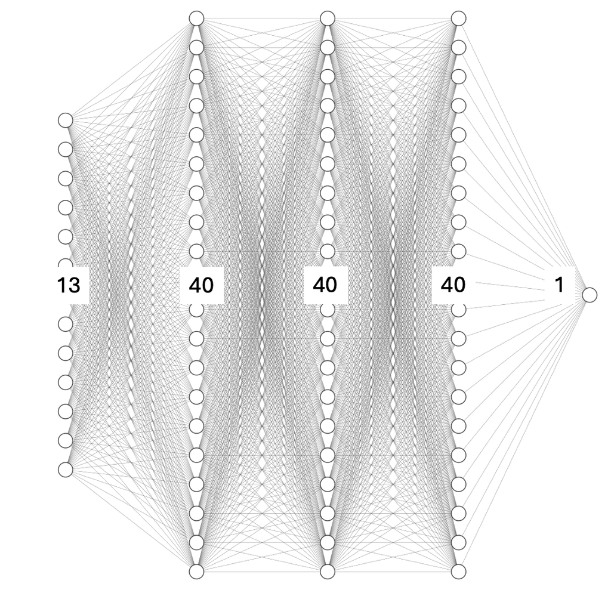

```python
(train_data, train_targets_raw), (test_data, test_targets_raw) = boston_housing.load_data()

data = np.concatenate([train_data, test_data])
targets = np.concatenate([train_targets_raw, test_targets_raw])

column_names = ['CRIM', 'ZN', 'INDUS', 'CHAS', 'NOX', 'RM', 'AGE', 'DIS', 'RAD', 'TAX', 'PTRATIO', 'B', 'LSTAT']
df = pd.DataFrame(data, columns=column_names)
df['MDEV'] = targets

df = df.sample(frac=1, random_state=42).reset_index(drop=True)

# Split: 65% train, 15% validation, 20% test
num_rows = df.shape[0]
train_size = int(num_rows * 0.65)
validation_size = int(num_rows * 0.15)

train_df = df.iloc[:train_size]
validation_df = df.iloc[train_size:train_size + validation_size]
test_df = df.iloc[train_size + validation_size:]

print(f"Training set size: {train_df.shape[0]}")
print(f"Validation set size: {validation_df.shape[0]}")
print(f"Testing set size: {test_df.shape[0]}")

train_targets = train_df['MDEV'].values
validation_targets = validation_df['MDEV'].values
test_targets = test_df['MDEV'].values

scaler = StandardScaler()
scaler.fit(train_df.drop('MDEV', axis=1))

train = scaler.transform(train_df.drop('MDEV', axis=1))
validation = scaler.transform(validation_df.drop('MDEV', axis=1))
test = scaler.transform(test_df.drop('MDEV', axis=1))

# Convert to PyTorch tensors
train_tensor = torch.tensor(train, dtype=torch.float32)
train_targets_tensor = torch.tensor(train_targets, dtype=torch.float32)
validation_tensor = torch.tensor(validation, dtype=torch.float32)
validation_targets_tensor = torch.tensor(validation_targets, dtype=torch.float32)
test_tensor = torch.tensor(test, dtype=torch.float32)
test_targets_tensor = torch.tensor(test_targets, dtype=torch.float32)

# Create datasets and dataloaders
batch_size = 32
train_dataset = TensorDataset(train_tensor, train_targets_tensor)
validation_dataset = TensorDataset(validation_tensor, validation_targets_tensor)
test_dataset = TensorDataset(test_tensor, test_targets_tensor)

train_loader = DataLoader(train_dataset, batch_size=batch_size, shuffle=True)
validation_loader = DataLoader(validation_dataset, batch_size=batch_size, shuffle=False)
test_loader = DataLoader(test_dataset, batch_size=batch_size, shuffle=False)
```

```
Training set size: 328
Validation set size: 75
Testing set size: 103
```

```python
# Model architecture: (13, 40, 40, 40, 1)
class RegressionModel(nn.Module):
    def __init__(self):
        super(RegressionModel, self).__init__()
        self.layer1 = nn.Linear(train.shape[1], 40)
        self.layer2 = nn.Linear(40, 40)
        self.layer3 = nn.Linear(40, 40)
        self.output_layer = nn.Linear(40, 1)

    def forward(self, x):
        x = torch.relu(self.layer1(x))
        x = torch.relu(self.layer2(x))
        x = torch.relu(self.layer3(x))
        x = self.output_layer(x)
        return x

loss_fn = nn.MSELoss()

# Training function
def train_model(model, train_loader, validation_loader, optimizer, loss_fn, epochs=100):
    train_losses = []
    validation_losses = []

    for epoch in range(epochs):
        model.train()
        train_loss = 0

        for inputs, targets in train_loader:
            optimizer.zero_grad()
            outputs = model(inputs)
            loss = loss_fn(outputs, targets.view(-1, 1))
            loss.backward()
            optimizer.step()
            train_loss += loss.item()
        train_mse = train_loss / len(train_loader)
        train_losses.append(train_mse)

        model.eval()
        validation_loss = 0
        with torch.no_grad():
            for inputs, targets in validation_loader:
                outputs = model(inputs)
                loss = loss_fn(outputs, targets.view(-1, 1))
                validation_loss += loss.item()
        validation_mse = validation_loss / len(validation_loader)
        validation_losses.append(validation_mse)

        if (epoch + 1) % 10 == 0:
            print(f'Epoch {epoch+1}/{epochs}, Train MSE: {train_mse:.4f}, Validation MSE: {validation_mse:.4f}')

    return train_losses, validation_losses

# Evaluation function
def evaluate_model(model, test_loader):
    model.eval()
    all_preds = []
    all_targets = []
    with torch.no_grad():
        for inputs, targets in test_loader:
            outputs = model(inputs)
            all_preds.append(outputs)
            all_targets.append(targets)
    y_pred = torch.cat(all_preds).cpu().numpy().flatten()
    y_true = torch.cat(all_targets).cpu().numpy().flatten()
    mae = mean_absolute_error(y_true, y_pred)
    mape = np.mean(np.abs((y_true - y_pred) / y_true)) * 100
    print(f"Test MAE: {mae:.1f}")
    print(f"Test MAPE: {mape:.1f}%")
    return y_pred, y_true

# Plot function
def plot_results(train_losses, validation_losses, y_pred, y_true, title):
    fig, axes = plt.subplots(1, 2, figsize=(14, 4))

    axes[0].plot(train_losses, label='Training Loss (MSE)')
    axes[0].plot(validation_losses, label='Validation Loss (MSE)')
    axes[0].set_title(f'{title} - Training and Validation Loss')
    axes[0].set_xlabel('Epochs')
    axes[0].set_ylabel('Loss (MSE)')
    axes[0].legend()

    y_test_sorted = np.sort(y_true)
    y_pred_sorted = np.sort(y_pred)
    axes[1].scatter(range(len(y_test_sorted)), y_test_sorted, label='Actual Values', marker='o')
    axes[1].scatter(range(len(y_pred_sorted)), y_pred_sorted, label='Predicted Values', marker='x')
    axes[1].set_title(f'{title} - Actual vs Predicted')
    axes[1].set_xlabel('Sample Index (sorted)')
    axes[1].set_ylabel('Target Values')
    axes[1].legend()
    axes[1].grid(True)

    plt.tight_layout()
    plt.show()
```

```python
results = {}
```

#### Part a) RMSprop Optimizer

```python
torch.manual_seed(42)
model_a = RegressionModel()
optimizer_a = optim.RMSprop(model_a.parameters(), lr=0.001, alpha=0.9, eps=1e-7, momentum=0.0, centered=False)

start_time = time.time()
train_losses_a, val_losses_a = train_model(model_a, train_loader, validation_loader, optimizer_a, loss_fn, epochs=100)
end_time = time.time()

print(f"Training time: {end_time - start_time:.2f} seconds")
print(f"Final Train MSE: {train_losses_a[-1]:.4f}")
```

```
Training time: 1.16 seconds
Final Train MSE: 10.2115
```

```
Test MAE: 2.3
Test MAPE: 10.8%
```

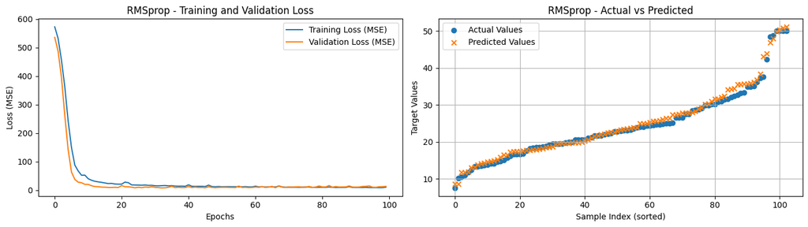

```python
y_pred_a, y_true_a = evaluate_model(model_a, test_loader)
plot_results(train_losses_a, val_losses_a, y_pred_a, y_true_a, 'RMSprop')
results['RMSprop'] = train_losses_a[-1]
```

#### Part b) SGD with No Momentum

```python
torch.manual_seed(42)
model_b = RegressionModel()
optimizer_b = optim.SGD(model_b.parameters(), lr=0.001, momentum=0.0)

start_time = time.time()
train_losses_b, val_losses_b = train_model(model_b, train_loader, validation_loader, optimizer_b, loss_fn, epochs=100)
end_time = time.time()

print(f"Training time: {end_time - start_time:.2f} seconds")
print(f"Final Train MSE: {train_losses_b[-1]:.4f}")
```

```
Training time: 0.86 seconds
Final Train MSE: 7.6797
```

```
Test MAE: 2.6
Test MAPE: 11.4%
```

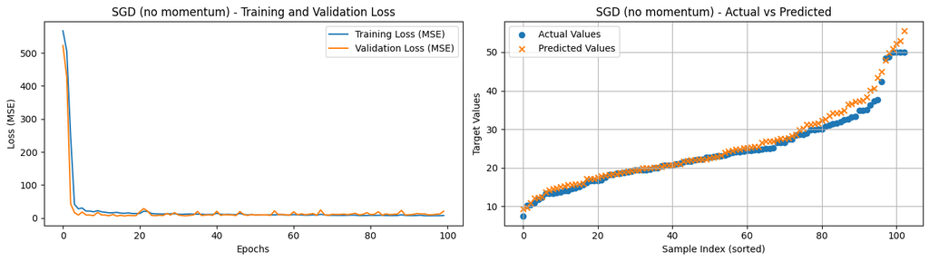

```python
y_pred_b, y_true_b = evaluate_model(model_b, test_loader)
plot_results(train_losses_b, val_losses_b, y_pred_b, y_true_b, 'SGD (no momentum)')
results['SGD (no momentum)'] = train_losses_b[-1]
```

#### Part c) SGD with Momentum

```python
torch.manual_seed(42)
model_c = RegressionModel()
optimizer_c = optim.SGD(model_c.parameters(), lr=0.001, momentum=0.9)

start_time = time.time()
train_losses_c, val_losses_c = train_model(model_c, train_loader, validation_loader, optimizer_c, loss_fn, epochs=100)
end_time = time.time()

print(f"Training time: {end_time - start_time:.2f} seconds")
print(f"Final Train MSE: {train_losses_c[-1]:.4f}")
```

```
Training time: 1.02 seconds
Final Train MSE: 2.3508
```

```
Test MAE: 2.2
Test MAPE: 10.3%
```

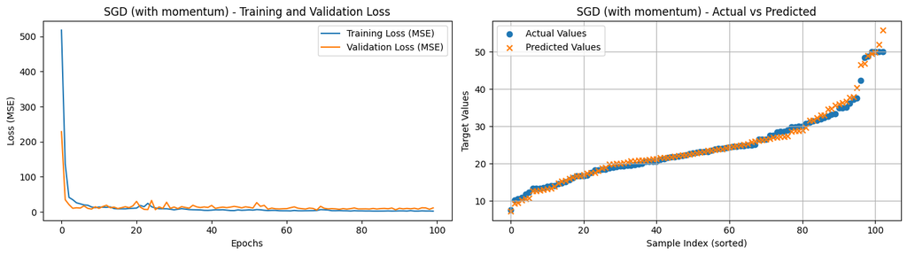

```python
y_pred_c, y_true_c = evaluate_model(model_c, test_loader)
plot_results(train_losses_c, val_losses_c, y_pred_c, y_true_c, 'SGD (with momentum)')
results['SGD (with momentum)'] = train_losses_c[-1]
```

#### Part d) Adam Optimizer

```python
torch.manual_seed(42)
model_d = RegressionModel()
optimizer_d = optim.Adam(model_d.parameters(), lr=0.001)

start_time = time.time()
train_losses_d, val_losses_d = train_model(model_d, train_loader, validation_loader, optimizer_d, loss_fn, epochs=100)
end_time = time.time()

print(f"Training time: {end_time - start_time:.2f} seconds")
print(f"Final Train MSE: {train_losses_d[-1]:.4f}")
```

```
Training time: 1.27 seconds
Final Train MSE: 8.8072
```

```
Test MAE: 2.2
Test MAPE: 10.2%
```

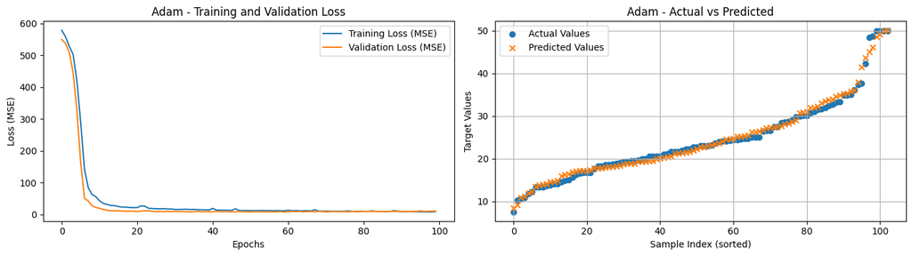

```python
y_pred_d, y_true_d = evaluate_model(model_d, test_loader)
plot_results(train_losses_d, val_losses_d, y_pred_d, y_true_d, 'Adam')
results['Adam'] = train_losses_d[-1]
```

#### Part e) Discussion

```
Final Training MSE after 100 epochs:
----------------------------------------
SGD (with momentum)      : 2.3508
SGD (no momentum)        : 7.6797
Adam                     : 8.8072
RMSprop                  : 10.2115
Best optimizer (lowest final train MSE): SGD (with momentum)
```

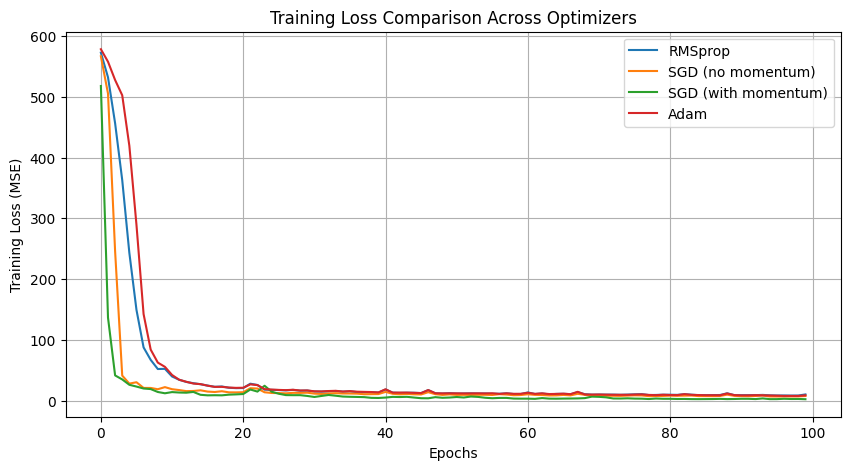

```python
# Compare all optimizers
print("Final Training MSE after 100 epochs:")
print("-" * 40)
for opt_name, final_loss in sorted(results.items(), key=lambda x: x[1]):
    print(f"{opt_name:25s}: {final_loss:.4f}")

best_optimizer = min(results, key=results.get)
print(f"Best optimizer (lowest final train MSE): {best_optimizer}")

# Plot all training losses together
plt.figure(figsize=(10, 5))
plt.plot(train_losses_a, label='RMSprop')
plt.plot(train_losses_b, label='SGD (no momentum)')
plt.plot(train_losses_c, label='SGD (with momentum)')
plt.plot(train_losses_d, label='Adam')
plt.title('Training Loss Comparison Across Optimizers')
plt.xlabel('Epochs')
plt.ylabel('Training Loss (MSE)')
plt.legend()
plt.grid(True)
plt.show()
```

#### Part e) Discussion

Based on the training results after 100 epochs, the final training MSE values are:

| Optimizer | Final Train MSE |
| --- | --- |
| SGD (with momentum) | 2.3508 |
| SGD (no momentum) | 7.6797 |
| Adam | 8.8072 |
| RMSprop | 10.2115 |

**Adam** (8.8072) and **RMSprop** (10.2115) both converged smoothly but settled at higher training losses. These adaptive optimizers scale learning rates per parameter using running averages of squared gradients, which can sometimes lead to premature convergence — the per-parameter learning rates shrink quickly, causing the optimizer to slow down before reaching a deeper minimum.

In summary, SGD with momentum led to the minimum training loss at the end of 100 epochs. While adaptive methods like Adam and RMSprop offer smoother and more stable convergence, the momentum-based SGD was able to reach a lower training loss in this setting. That said, the high gap between training and validation loss for SGD with momentum suggests that lower training loss does not necessarily mean better generalization.